# Chimpanzees Analysis, continued

Jessi Kehe

This R Markdown document was adapted from documents created by Professor Bret Larget.

### Setup details

- You will need the packages `tidyverse` for these lectures.
- This assumes you have the R script `viridis.R` and `ggprob.R` two steps back from the working directory (`"../../scripts/viridis.R"`, `"../../scripts/ggprob.R"`). Be sure to adjust the code if you have these scripts in different locations.
- The following data files will be used and are assumed to be located two steps back from the working directory in a folder called `data/`. Be sure to adjust the code if you have the data files in a different location.  
  `"../../data/chimpanzee.csv"`

# Lecture: Introduction to Hypothesis Tests for p

## Recall: Case Study

- Chimpanzees were studied in a pro-social choice experiment.
  - Chimpanzees are given a sequence of choices about which color token to select.
  - One color (labeled selfish) results in them getting food.
  - Another (labeled pro-social) results in both them and a partner chimp receiving food.
  - In a control setting, there is no partner
    - different color choices result in the researcher mimicking the same actions as when partner is present (i.e., always giving the actor chimp food, making a motion with food toward the empty room for the partner chimp).
- We will develop a statistical model for this experiment.
- Each part of the experiment includes a series of 30 trials where one of two outcomes is possible.

## Recall: Inference questions

- How often does the actor chimpanzee make the pro-social choice? How much uncertainty is there in this estimate? How confident can we be that the long-run probability of making the pro-social choice in repeated trials falls within some interval?
- Do chimps make the pro-social choice more than 50 percent of the time, or is the pro-social choice made at random?
- Does the frequency with which the chimpanzee makes the pro-social choice depend on there being a partner chimpanzee in the neighboring room?

## Recall: Partial Data

- One chimpanzee (subject A) was tested 90 times with a partner (three sets of 30 trials with each of three different partners)
- The chimpanzee made the pro-social choice 60 times out of 90 trials.

## Recall: A Statistical Model

1. Name and define variables
2. Make assumptions (these can be examined later)
3. Write a probability model for the variables and required parameters
- $X$ is the number of pro-social choices that subject A makes in 90 trials.
- Assume:
  - each trial could be pro-social or selfish
  - 90 trials was predetermined
  - trials are independent (this assumption is debatable)
  - same probability of pro-social choice for each trial (this assumption is debatable)
- Under these assumptions, $X$ has a binomial distribution.
- Parameters are:
  - $n$, the number of trials. Here $n=90$.
  - $p$, an unknown long-run probability that this chimpanzee makes the pro-social choice. (We may be interesting in inference on this parameter using the data.)

The model is:

$$X \mid p \sim \text{Binomial}(n,p)$$

The data are:

- $n=90$
- $x=60$

## Hypothesis Tests

- When finding a confidence interval, we are trying to estimate an unknown parameter, such as $p$.
- For a *hypothesis test*, we often examine the data to see if the data are *consistent with the parameter having a specific fixed value* versus an alternative where it is different.
- Typically, the null hypothesis represents a condition of no effect.
- In the chimpanzee example, it makes sense to pose these null hypothesis and alternative hypotheses.
  - $H_0: p = 0.5$
  - $H_a: p \neq 0.5$
- The null hypothesis is what we would expect if the chimpanzee were choosing colored tokens at random.
- The alternative hypothesis is the long-run probability is something other than 0.5. This difference may be interpreted as willful behavior by the chimpanzee to do something (whether acting in a pro-social or selfish way more often than expected).

# Lecture: Hypothesis Tests for p

## Hypothesis Steps

1. State the statistical model for the data
2. State hypotheses
3. Choose a test statistic
4. Determine the sampling distribution of the test statistic when the null hypothesis is true.
5. Determine which outcomes are *at least as extreme as the observed test statistic*, or *which outcomes are at least as favorable to the alternative hypothesis as the observed test statistic* and find the collective probability of these outcomes. This probability is called a *p-value*.
6. Use the p-value to interpret the strength of evidence against the null hypothesis.
   - Conventional choices are to call:
     - $p < 0.05$ *statistically significant*;
     - $p < 0.01$ *highly statistically significant*.
7. Interpret the result in context, summarizing the statistical evidence by referring to the p-value and test.

## Example

Our chimpanzee made the pro-social choice 60 times out of 90.

1. Model:

$$X \mid p \sim \text{Binomial}(n,p)$$

2. State hypotheses:

$$H_0: p = 0.5 \\
H_a: p \neq 0.5$$

3. Test statistic is $X$. (You might have learned to use $\hat{p}$ in an AP Stat course.)
4. If the null hypothesis is true, then

$$X \sim \text{Binomial}(90,0.5)$$

5. Any outcome as likely or less likely than observing $X=60$ would provide evidence against $p=0.5$ at least as strongly as the observed value.

The $\text{Binomial}(90,0.5)$ distribution has mean 45 and is symmetric, which suggests outcomes 30 or smaller or 60 or higher have the same or smaller probability as $X=60$ under the null hypothesis.

This is the distribution we assume is true (based on the null hypothesis).

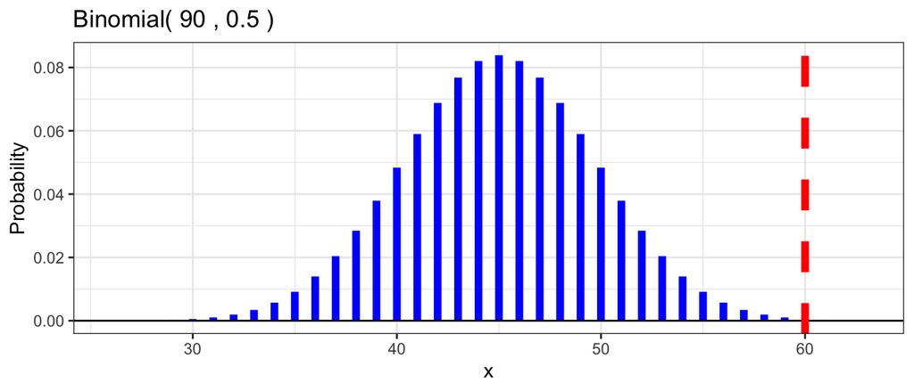

```r
gbinom(90,0.5,scale=TRUE, size = 2) +
  geom_vline(xintercept=60,color="red",
             linetype="dashed", size = 2) +
  theme_bw()
```

Next, we calculate the p-value.

Because I do not like to check equality for continuous values (there can be numerical issues that arise), I will introduce a small tolerance and look for $x$ value whose probability is less than the probability of exactly 60 successes plus the tolerance.

```r
tol <- 1.0e-07 ## 10 ^(-7)
x <- 0:90
x_extreme <- x[dbinom(x,90,0.5) < dbinom(60,90,0.5) + tol]
x_extreme
```

```
##  [1]  0  1  2  3  4  5  6  7  8  9 10 11 12 13 14 15 16 17 18 19 20 21 22 23 24
## [26] 25 26 27 28 29 30 60 61 62 63 64 65 66 67 68 69 70 71 72 73 74 75 76 77 78
## [51] 79 80 81 82 83 84 85 86 87 88 89 90
```

```r
p_value <- sum(dbinom(x_extreme,90,0.5))
p_value
```

```
## [1] 0.002060266
```

```r
pbinom(59,90,.5,lower.tail=FALSE)*2 # P(X > 59) = P(X >= 60)
```

```
## [1] 0.002060266
```

```r
pbinom(30,90,.5,lower.tail=TRUE)*2  # P(X <= 30)
```

```
## [1] 0.002060266
```

6. The p-value is about 0.0021 which is about 1 in 485. This is highly statistically significant.

If the null hypothesis were true, we would expect to see a result this extreme only about once per every 485 experiments, yet it happened. There is strong evidence that the null hypothesis is false and that the true value of $p$ is closer to the observed proportion of $\hat{p} \approx 0.667$.  
- It is more plausible that $p$ is not 0.5 and we just observed typical data, than it is that $p=0.5$ and we just witnessed a very improbable outcome.

7. There is very strong evidence ($p \approx 0.0021$, two-sided binomial test) that the chimpanzee in this experiment will make the pro-social choice more than half the time in the experimental settings.

# Lecture: More on hypothesis testing

- To carryout a hypothesis test, a test statistic is specified which allows us to measure the compatibility between the null hypothesis and the data.
  - In our previous chimpanzee example, the chimpanzee made the pro-social choice 60 times out of 90. Our test statistic was $x = 60$ (the observed realization of our binomial random variable). We were then able to measure the compatibility between $X=60$ and the null hypothesis with $p = .5$.
- The p-value contributes to quantifying this compatibility.
  - The p-value is the probability of observing what we did for the test statistic (e.g., $X=60$) or something more extreme in the direction of the alternative hypothesis. In the previous chimpanzee example, we considered the *two-sided* alternative of $p \neq 0.5$ so we looked to both tails to estimate the p-value.
    - If we used $H_a: p > 0.5$, then we would be looking in the *upper* tail to compute the p-value ($P(X \geq 60)$)
    - If we used $H_a: p < 0.5$, then we would be looking in the *lower* tail to compute the p-value ($P(X \leq 60)$); note that this would result in a p-value > 0.50.
  - Smaller p-values are evidence *against* the null hypothesis.
- Failing to find statistical significance means the null hypothesis is *not* rejected. Note that this is not the same as *accepting* the null hypothesis.

#### Simple example

> A noted psychic was tested for extrasensory perception (ESP). The psychic was presented with 200 cards face down and asked to determine if the cards were one of five symbols: a star, a cross, a circle, a square, or three wavy lines. The psychic was correct in 50 cases. Let p represent the probability that the psychic correctly identifies the symbol on the card in a random trial. Assume the 200 trials can be treated as a simple random sample from the population of all guesses the psychic would make in his lifetime. Specify a hypothesis test to determine if this psychic did better than random guessing, and carryout the hypothesis test with the sample. [These numbers are made-up and are not based on an actual study.]

They psychic made the correct choice 50 times out of 200.

1. Model: $X \mid p \sim \text{Binomial}(n,p)$
2. State hypotheses:

$$H_0: p = 0.2 \\
H_a: p > 0.2$$
3. Test statistic is $X$.

4. If the null hypothesis is true, then

$$X \sim \text{Binomial}(200,0.2)$$

5. Outcomes great than or equal to $X=50$ would provide evidence against $p=0.2$.

The $\text{Binomial}(200,0.2)$ distribution has mean 40.

This is the distribution we assume is true (based on the null hypothesis).

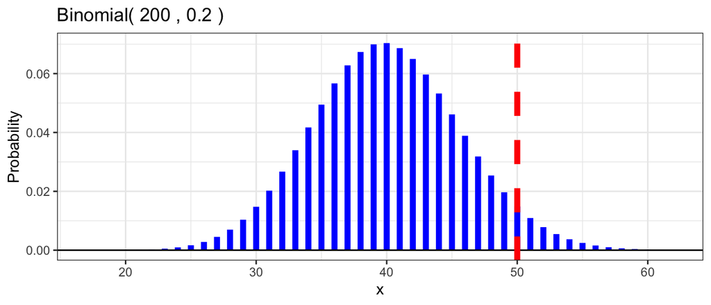

```r
gbinom(200,0.2,scale=TRUE, size = 2) +
  geom_vline(xintercept=50,color="red",
             linetype="dashed", size = 2) +
  theme_bw()
```

Next, we calculate the p-value.

```r
p_value <- pbinom(49,200,.2,lower.tail=FALSE) # P(X > 49) = P(X >= 50)
p_value
```

```
## [1] 0.04935333
```

The p-value is 0.0494, which is borderline significant. If we set the significance level to 0.05, we would reject the null hypothesis that the psychic was randomly guessing.

# Lecture: CI for a Difference of Proportions

## Data

```r
chimps <- read_csv("../../data/chimpanzee.csv") %>%
  mutate(with_partner = case_when(
    partner == "none" ~ FALSE,
    TRUE ~ TRUE)) %>%
  select(actor,partner,with_partner,everything())

chimps
```

```
## # A tibble: 27 x 7
##    actor partner with_partner prosocial selfish prosocial_color selfish_color
##    <chr> <chr>   <lgl>            <dbl>   <dbl> <chr>           <chr>
##  1 A     I       TRUE                22       8 green           purple
##  2 A     G       TRUE                16      14 yellow          black
##  3 A     H       TRUE                22       8 blue            red
##  4 A     none    FALSE               16      14 pink            gray
##  5 B     H       TRUE                18      12 black           yellow
##  6 B     C       TRUE                23       7 purple          green
##  7 B     D       TRUE                19      11 blue            red
##  8 B     none    FALSE               16      14 gray            pink
##  9 C     B       TRUE                18      12 yellow          black
## 10 C     F       TRUE                19      11 red             blue
## # … with 17 more rows
```

### 1

> Does chimpanzee C make the pro-social choice more often when there is a partner in the neighboring room?

```r
chimp_c <- chimps %>%
  filter(actor == "C") %>%
  group_by(with_partner) %>%
  summarize(prosocial = sum(prosocial),
            selfish = sum(selfish),
            n = prosocial + selfish,
            p_hat = prosocial / n)
chimp_c
```

```
## # A tibble: 2 x 5
##   with_partner prosocial selfish     n p_hat
##   <lgl>            <dbl>   <dbl> <dbl> <dbl>
## 1 FALSE               17      13    30 0.567
## 2 TRUE                57      33    90 0.633
```

- The point estimates are 63.3% with a partner and 56.7% without a partner.
- Is this difference significant?
- We will consider multiple approaches.

#### Statistical Model

The statistical model is:

- $p_1$ is the probability that Chimpanzee C makes the pro-social choice when there is a partner
- $p_2$ is the probability that Chimpanzee C makes the pro-social choice when there is no partner

$$X_1 \mid p_1 \sim \text{Binomial}(90,p_1) \\
X_2 \mid p_2 \sim \text{Binomial}(30,p_2)$$

#### Confidence Interval for a Difference Formula

Here is the SE for a difference in proportions.

$$\text{SE}(p_1 - p_2) =
\sqrt{ \frac{p_1(1-p_1)}{n_1} + \frac{p_2(1-p_2)}{n_2} }$$

I will use an Agresti-Coull-style estimate by using

$$\tilde{p} = \frac{x+2}{n+4}$$
for the point estimate instead of the maximum likelihood estimate
$$\hat{p} = \frac{x}{n}$$

```r
chimp_c <- chimp_c %>%
  mutate(p_tilde = (prosocial+2)/(n+4),
         se = sqrt(p_tilde*(1-p_tilde)/(n+4)))

## 95% CI for difference in proportions
est_c_diff <- chimp_c$p_tilde[2] - chimp_c$p_tilde[1]
est_c_diff
```

```
## [1] 0.06883605
```

```r
se_c_diff <- sqrt(chimp_c$se[1]^2 + chimp_c$se[2]^2)
se_c_diff
```

```
## [1] 0.09867813
```

```r
z <- qnorm(0.975)
ci_c_diff <- est_c_diff + c(-1,1) * z * se_c_diff
ci_c_diff
```

```
## [1] -0.1245695  0.2622416
```

- The 95% confidence interval for the difference extends from the pro-social probability with a partner being anywhere from 12.5% lower to 26.2% higher than the pro-social choice without a partner.
- This is consistent with there being no difference in the probabilities.

# Lecture: CI for a Difference of Proportions Simulation

We will estimate our confidence interval using simulated data. To do this, we will

- Assume the maximum likelihood estimates for each sample
- Simulate the outcomes many times
- Estimate the SE for the difference between the sample proportions
- Assume a normal distribution for the distribution

```r
N <- 100000 ## number of repetitions

df <- tibble( ## data frame with our simulated sample proportions and differences
  p_hat_1 = rbinom(N,90,chimp_c$p_hat[2]) / 90,
  p_hat_2 = rbinom(N,30,chimp_c$p_hat[1]) / 30,
  diff = p_hat_1 - p_hat_2)

ci_rand <- df %>% ## estimate the confidence interval
  summarize(se = sd(diff), ## standard deviation of the differences
            est = chimp_c$p_hat[2] - chimp_c$p_hat[1],  ## our estimated difference
            z = qnorm(0.975),  ## the normal quantile for a 95% CI
            a = est - z*se,  ## lower bound on interval
            b = est + z*se)  ## upper bound on interval
ci_rand
```

```
## # A tibble: 1 x 5
##      se    est     z      a     b
##   <dbl>  <dbl> <dbl>  <dbl> <dbl>
## 1 0.104 0.0667  1.96 -0.137 0.270
```

When computing the confidence interval, we assume that the distribution of the difference is approximately normal. We can check this assumption by plotting the density of the differences (think of it as a smooth histogram), along with the assumed normal distribution.

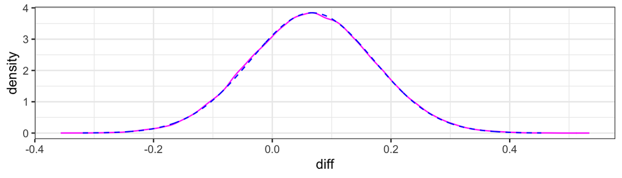

```r
## examine approximate normal assumption
ggplot(df, aes(x=diff)) +
  geom_density(color="magenta") +
  geom_norm_density(mu = mean(df$diff), sigma = sd(df$diff), color="blue", linetype="dashed") +
  theme_bw()
```

- The normal approximation appears to be excellent.

# Lecture: Hypothesis test for a Difference of Proportions Simulation

#### Hypothesis Test: Normal Distribution

Since the normal approximation appears to hold, we can use this assumption to carryout a hypothesis test on the differences. We will consider the null to be the case where the two proportions are equal with a two-sided alternative.

$$H_0: p_1 = p_2 \\
H_a: p_1 \neq p_2$$

- The test statistic is

$$z = \frac{\hat{p}_1 - \hat{p}_2}{\text{SE}(\hat{p}_1 - \hat{p}_2)}$$

- When the null hypothesis is true, the test statistic has an approximate standard normal distribution.
- Recall that if $X \sim N(\mu, \sigma)$, then $Z = \frac{X-\mu}{\sigma} \sim N(0,1)$
- Estimate the test statistic under the assumption that the null hypothesis is true.
  - This means the estimate for $\text{SE}(\hat{p}_1-\hat{p}_2)$ should assume that $p_1 = p_2$.
  - There are a total of 17 + 57 = 74 pro-social choices in 30 + 90 = 120 trials.

```r
df_d <- chimp_c %>%
  ungroup() %>%
  summarize(est = p_hat[2] - p_hat[1],
            prosocial = sum(prosocial),
            n_1 = n[2],
            n_2 = n[1],
            n = sum(n),
            p_pool = prosocial/n,
            se_pool = sqrt(p_pool*(1-p_pool)*(1/n_1 + 1/n_2)),
            z = est / se_pool,
            p_value = 2*pnorm(-abs(z)))

df_d
```

```
## # A tibble: 1 x 9
##      est prosocial   n_1   n_2     n p_pool se_pool     z p_value
##    <dbl>     <dbl> <dbl> <dbl> <dbl>  <dbl>   <dbl> <dbl>   <dbl>
## 1 0.0667        74    90    30   120  0.617   0.102 0.650   0.515
```

The data are consistent ($z=0.65$, p_value=0.52, Z-test for a difference in proportions) with there being no difference in the probability that Chimpanzee C makes the pro-social choice when there is a partner or when there is no partner.

#### Randomization P-Value

- Note the difference in the randomization in the assumed value for $p$.
  - Under the null hypothesis, $p_1=p_2$ so we use the pooled estimate to generate the samples

```r
N <-  100000  ## number of repetitions
df_e <- tibble(
  p_hat_1 = rbinom(N,90,df_d$p_pool) / 90,
  p_hat_2 = rbinom(N,30,df_d$p_pool) / 30,
  diff = p_hat_1 - p_hat_2,
  extreme = abs(diff) >= abs(df_d$est)) ## compare simulated differences to our observed difference

p_value_e <- mean(df_e$extreme)

p_value_e
```

```
## [1] 0.55376
```

We can check the normality assumption again. The center of the normal density, under the null hypothesis, should be zero.

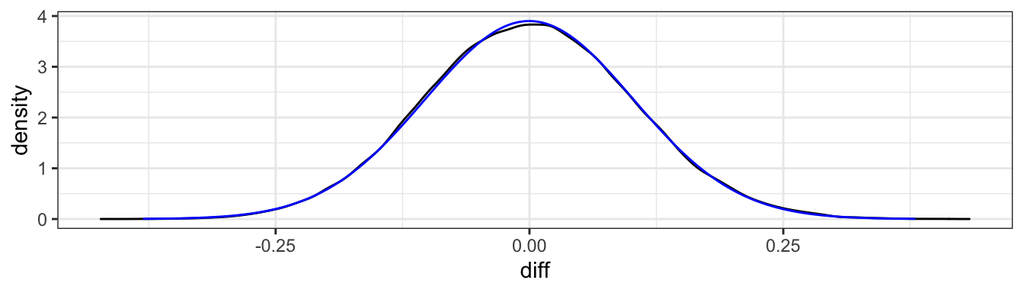

```r
ggplot(df_e, aes(x=diff)) +
  geom_density() +
  geom_norm_density(mu = mean(df_e$diff), sd(df_e$diff)) +
  theme_bw()
```

Again, the normality assumption appears to be satisfied.

# Lecture: Chimpanzees and Likelihood Ratio Tests

Previously we only considered the data for one of the chimpanzee actors (subject A, who made the pro-social choice 60 times out of 90). However, we have data on seven actors.

```r
chimps %>%
  distinct(actor)
```

```
## # A tibble: 7 x 1
##   actor
##   <chr>
## 1 A
## 2 B
## 3 C
## 4 D
## 5 E
## 6 F
## 7 G
```

We will discuss how to carryout a hypothesis test for all seven chimpanzees!

#### Recall: Likelihood Functions

Suppose $X \mid p \sim \text{Binomial}(n,p)$.

The probability mass function for the binomial distribution is

$$P(X = x) = {n\choose x}p^x(1-p)^{n-x}$$

Once we observe a value for $x$, we can consider $P(X = x)$ to be a function of the parameter $p$ instead of as a function of $x$. This new function is referred to as a *likelihood function*.

$$L(p \mid X=x) = {n\choose x}p^x(1-p)^{n-x}$$

#### Statistical Model

- Assume a binomial model for each chimpanzee with a separate value for $p_i$ for the $i$th chimpanzee where $p_i$ represent the long-run probability of selecting the pro-social token when there is a partner in the neighboring room.

$$X_i \mid p_i \sim \text{Binomial}(n_i,p_i), \quad \text{for $i=1,\ldots,7$}$$

#### Likelihood Ratio Test

$$H_0: p_1 = \ldots = p_7 \\
H_a: \text{not}~ p_1 = \ldots = p_7$$

- The null hypothesis is that all of the pro-social probabilities are the same.
- The alternative hypothesis is that they are not all the same (at least one is different).
- If $L_0$ is the maximum likelihood of the data under the null hypothesis and $L_1$ is the maximum likelihood of the data under the alternative hypothesis, the likelihood ratio is $R = L_0/L_1$.
- As likelihoods might be very small, we often take the natural log of this ratio.
- Furthermore, we often multiply by $-2$;
  - negative so that the log is positive because $R \le 1$.
  - $-2$ because theory says then the ratio can be compared to a chi-square distribution.
- Therefore, we use $G = -2 \times \left(\ln L_0 - \ln L_1 \right)$ for this hypothesis test.

```r
df_2 <- chimps %>%
  filter(with_partner == TRUE) %>%
  group_by(actor) %>%
  summarize(prosocial = sum(prosocial),
            selfish = sum(selfish),
            n = prosocial + selfish,
            p_hat = prosocial/n)

df_2
```

```
## # A tibble: 7 x 5
##   actor prosocial selfish     n p_hat
##   <chr>     <dbl>   <dbl> <dbl> <dbl>
## 1 A            60      30    90 0.667
## 2 B            60      30    90 0.667
## 3 C            57      33    90 0.633
## 4 D            50      40    90 0.556
## 5 E            48      42    90 0.533
## 6 F            47      43    90 0.522
## 7 G            37      33    70 0.529
```

```r
df_2_0 <- df_2 %>%
  ungroup() %>%
   summarize(prosocial = sum(prosocial),
             selfish = sum(selfish),
             n = prosocial + selfish,
             p_hat = prosocial/n)

df_2_0
```

```
## # A tibble: 1 x 4
##   prosocial selfish     n p_hat
##       <dbl>   <dbl> <dbl> <dbl>
## 1       359     251   610 0.589
```

#### Calculations

- Instead of calculating $R$, calculate instead $-2\ln R$.
- This is $G = -2 (\ln L_0 - \ln L_1) = 2(\ln L_1 - \ln L_0)$.
- So, we seek twice the difference in log-likelihoods.
- The log-likelihood under the null hypothesis is just the sum of the logs of the binomial probabilities of obtaining the individual success counts when all $p_i$ are estimated to be $359/610$.
- The log-likelihood under the alternative hypothesis is the sum of the log-likelihoods for each of the seven different binomial probabilities, each with its own estimate of $p$.
- We can use the `log` argument to `dbinom()` to return the natural log of the probability instead of the probability itself.
- Use `dplyr` code to do the calculations.

```r
df_2 <- df_2 %>%
  mutate(p_0 = sum(prosocial)/sum(n)) %>%
  mutate(log_L0 = dbinom(prosocial,n,p_0,log=TRUE),
         log_L1 = dbinom(prosocial,n,p_hat,log=TRUE))

lrt <- df_2 %>%
  summarize(log_L0 = sum(log_L0),
            log_L1 = sum(log_L1),
            lrt = 2*(log_L1 - log_L0),
            R = exp(log_L0-log_L1))
lrt
```

```
## # A tibble: 1 x 4
##   log_L0 log_L1   lrt       R
##    <dbl>  <dbl> <dbl>   <dbl>
## 1  -21.8  -17.1  9.56 0.00838
```

At this point we have calculated the LRT statistic $G = -2\ln R = -2 (\ln L_0 - \ln L_1) = 2(\ln L_1 - \ln L_0) =$ 9.564.  
In the next lecture, we will discuss how to calculate a p-value from this.

# Lecture: Chimpanzees and Likelihood Ratio Tests p-value

### Chi-square approach to the p-value

- Theory says that if the sample sizes are large enough, then the sampling distribution of the LRT statistic has an approximate chi-square distribution with degrees of freedom equal to the difference in the number of free parameters between the two hypotheses.
- Here the null hypothesis has 1 free parameter to estimate.
- The alternative hypothesis has 7.
- So, we want to compare to a chi-square distribution with 6 degrees of freedom.
  - This is the distribution you would get by taking 6 independent standard normal random variables, squaring them, and summing up the squared values.
  - The mean is the number of degrees of freedom, here 6.
  - The standard deviation is the square root of twice the degrees of freedom, or here $\sqrt{12} \approx 3.46$.
  - The p-value is always the area under the density curve to the right. This is because the LRT statistic is larger when $\ln L_1$ is larger – that is, when the likelihood under the alternative model is even higher than the null. This lends more evidence against the null hypothesis in favor of the alternative hypothesis.

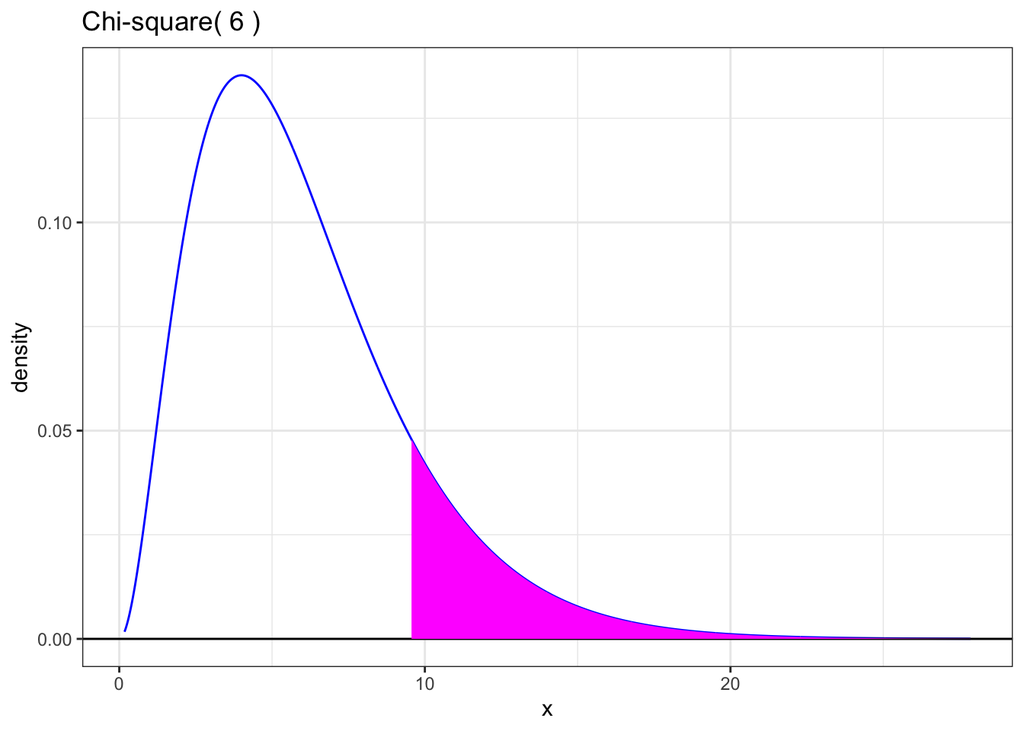

```r
gchisq(6) +
  geom_chisq_fill(df=6,a=lrt$lrt,b=qchisq(0.9999,6),fill="magenta") +
  theme_bw()
```

```r
## calculate the p-value
lrt <- lrt %>%
  mutate(p_value = 1 - pchisq(lrt,6))
lrt
```

```
## # A tibble: 1 x 5
##   log_L0 log_L1   lrt       R p_value
##    <dbl>  <dbl> <dbl>   <dbl>   <dbl>
## 1  -21.8  -17.1  9.56 0.00838   0.144
```

- The p-value is not significant.
  - We would expect a result at least this extreme about once every 7 experiments.
  - If I guessed the day of the week you were born and I got it right, would you be surprised?
  - A little bit, but a 1 in 7 chance is not that unusual.

### Conclusion

> The observed data is consistent with all seven chimpanzees having the same probability of making the pro-social choice when there is a partner ($p=0.144$, $G = 9.56$, likelihood ratio test).

# Lecture: Chimpanzees and Likelihood Ratio Randomization Test

- Rather than relying on theory, we instead could calculate a p-value by simulating the sampling distribution of the LRT statistic, *assuming that the null hypothesis is true*.
- We will write a function to do the work.

Write a function to calculate the LRT statistic from an input data frame with columns:  
- prosocial  
- selfish  
- n

```r
lrt_stat <- function(df){ ## Calculate the LRT statistic
  df <- df %>%
    mutate(p_0 = sum(prosocial)/sum(n),
           p_hat = prosocial/n,
           log_L0 = dbinom(prosocial,n,p_0,log=TRUE),
           log_L1 = dbinom(prosocial,n,p_hat,log=TRUE)) %>%
    summarize(lrt = 2*(sum(log_L1) - sum(log_L0)))
  return( df$lrt )
}

### Test this with our df_2 from earlier; we should get 9.563735
lrt_stat(df_2)
```

```
## [1] 9.563735
```

Instead of using dplyr, let’s write the function in a vectorized form.

```r
lrt_stat_vector <- function(df)
{
  x <- df$prosocial
  n <- df$n
  p_0 <- sum(x)/sum(n)
  p_hat <- x/n
  log_L0 <- sum(dbinom(x,n,p_0,log=TRUE))
  log_L1 <- sum(dbinom(x,n,p_hat,log=TRUE))
  return( 2*(log_L1 - log_L0) )
}

### Test this with our df_2 from earlier; we should get 9.563735
lrt_stat_vector(df_2)
```

```
## [1] 9.563735
```

We can compare the time it takes to compute the LRT using the two different function to help us decide which one to use.

```r
## Test the time for the dplyr and vector versions of the
##   functions to calculate the test statistic
system.time( {for(i in 1:1000) lrt_stat(df_2)} )
```

```
##    user  system elapsed
##   3.779   0.043   3.884
```

```r
system.time( {for(i in 1:1000) lrt_stat_vector(df_2)} )
```

```
##    user  system elapsed
##   0.014   0.000   0.014
```

The `system.time()` function calls the `proc.time()` function. The R documentation explains the three numbers: “The first two entries are the total user and system CPU times of the current R process and any child processes on which it has waited, and the third entry is the ‘real’ elapsed time since the process was started.”

Our vectorized function is faster! Let’s use it.

This next function allows us to generate a specified number of repetitions, `N`, and calculate the `lrt`.

```r
lrt_randomization <- function(df,N=100000)
{
  m <- nrow(df)
  p_0 <- df %>%
    summarize(p_0 = sum(prosocial)/sum(n)) %>%
    pull(p_0)

  lrt <- numeric(N)
  for ( i in 1:N )
  {
    df_rand <- df %>%
      mutate(prosocial = rbinom(m,n,p_0))
    lrt[i] = lrt_stat_vector(df_rand)
  }
  return( lrt )
}
```

And now we can calculate

```r
lrt <- df_2 %>%
  select(prosocial,n) %>%
  lrt_randomization()

lrt_0 <- lrt_stat(df_2)
p_value <- mean(lrt >= lrt_0)
signif(p_value,4)
```

```
## [1] 0.1477
```

```r
## Compare
signif(1 - pchisq(lrt_0,6),4)
```

```
## [1] 0.1443
```

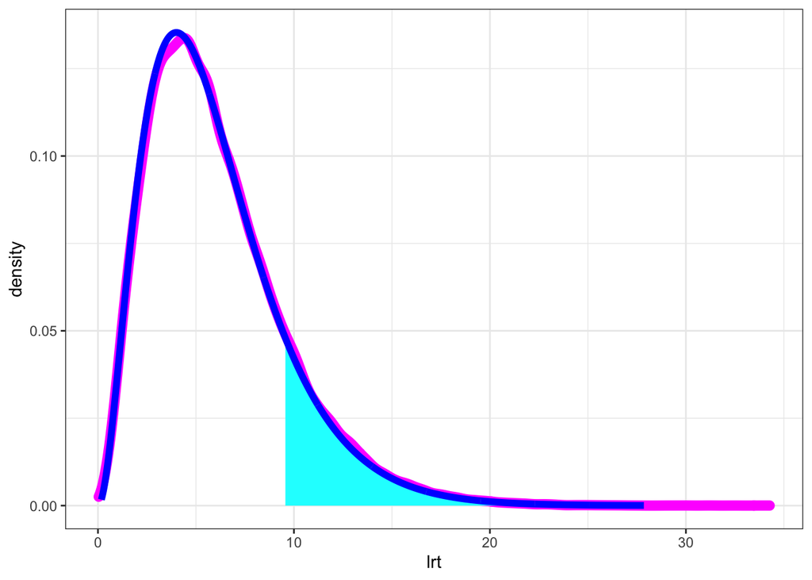

```r
## Check plot
df_lrt <- tibble(lrt)

ggplot(df_lrt, aes(x=lrt)) +
  geom_density(color="magenta",size=3) +
  geom_chisq_fill(df=6,a=lrt_0, fill="cyan") +
  geom_chisq_density(df=6, color="blue", size=2) +
  theme_bw()
```

- We see that the randomization distribution is a close fit to the theoretical value.